# Mixed Models for TMT: Mouse Diet Case Study

Author

Affiliation

Lieven Clement

Ghent University

Solution of the TMT exercise in the design tutorial.

# 1 Load packages

```r
library("msqrob2")
library("dplyr")
library("ggplot2")
library("patchwork")
library("BiocParallel")
register(SerialParam())
```

# 2 Experimental context

The data used in this exercise has been published by Plubell et al. (2017) (PXD005953). The objective of the experiment was to explore the impact of low-fat and high-fat diets on the proteomic content of adipose tissue in mice. It also assesses whether the duration of the diet may impact the results. The authors assigned twenty mice into four groups (5 mice per group) based on their diet, either low-fat (LF) or high-fat (HF), and the duration of the diet, which was classified as short (8 weeks) or long (18 weeks). Samples from the epididymal adipose tissue were extracted from each mice. The samples were then randomly distributed across three TMT 10-plex mixtures for analysis. In each mixture, two reference labels were used, each containing pooled samples that included a range of peptides from all the samples. Not all labels were used, leading to an unbalanced design. Each TMT 10-plex mixture was fractionated into nine parts, resulting in a total of 27 MS runs.

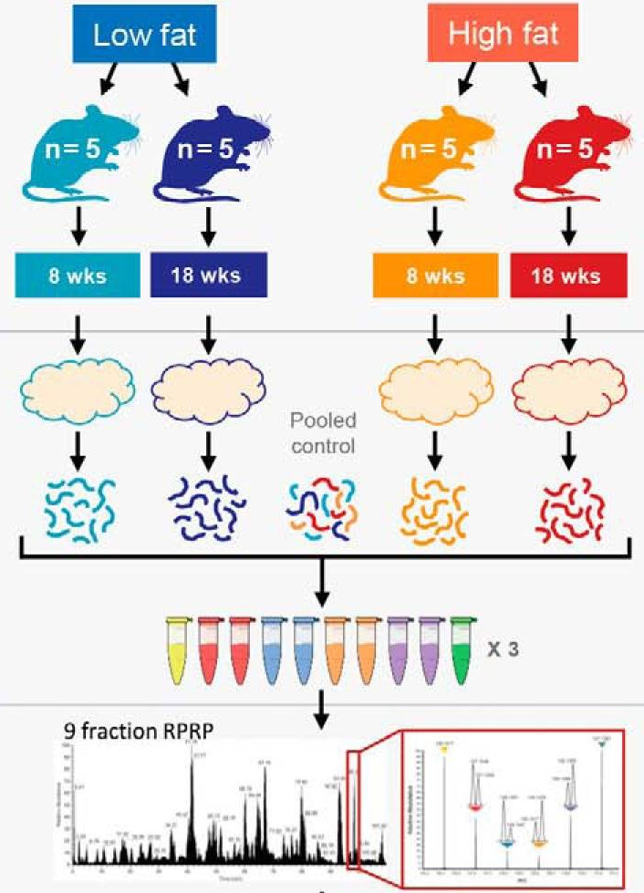

Overview of the experimental design. Taken from Plubell et al. 2017.

# 3 Data

The data were reanalyzed by Huang et al. (2020) and have been deposited in the `MSV000084264` MASSiVE repository, but we will retrieve the timestamped data from our [Zenodo repository](https://zenodo.org/records/14767905). We need 2 files: the Skyline identification and quantification table generated by the authors and the sample annotation files.

```r
library("BiocFileCache")
bfc <- BiocFileCache()
psmFile <- bfcrpath(bfc, "https://zenodo.org/records/14767905/files/mouse_psms.txt?download=1")
annotFile <- bfcrpath(bfc, "https://zenodo.org/records/14767905/files/mouse_annotations.csv?download=1")
```

Let’s prepare the data. We will also subset the data set to reduce computational costs. We here randomly sample 500 proteins from the experiment.

```r
## Reading data
psms <- read.delim(psmFile)
coldata <- read.csv(annotFile)
coldata$Duration <- gsub("_.*", "", coldata$Condition) ## 1.
coldata$Diet <- gsub(".*_", "", coldata$Condition) ## 2.
colnames(coldata)[1] <- "Label" ## 3.
## Subsetting data
proteinIds <- unique(psms$Protein.Accessions)
set.seed(1234)
psms <- psms[psms$Protein.Accessions %in% sample(proteinIds, 500), ]
## Converting data
coldata$runCol <- coldata$Run
coldata$quantCols <- paste0("Abundance..", coldata$Label)
mouse <- readQFeatures(psms, colData = coldata,
                       quantCols = unique(coldata$quantCols),
                       runCol = "Spectrum.File", name = "psms")
names(mouse) <- sub("^.*(Mouse.*ACN).*raw", "\\1", names(mouse))
```

# 4 Data preprocessing

We use the same data processing workflow as for the spike-in study in the TMT lecture: median of ratios normalisation and maxLFQ summarisation, both performed run by run.

```r
inputNames <- names(mouse)
logNames <- paste0(inputNames, "_log")
normNames <- paste0(inputNames, "_norm")
summNames <- paste0(inputNames, "_proteins")
## Encode missing values
mouse <- zeroIsNA(mouse, inputNames)
## Log transformation
mouse <- logTransform(mouse, inputNames, name = logNames, base = 2)
## Sample filtering
mouse <- subsetByColData(
    mouse, mouse$Condition != "Norm" & mouse$Condition != "Long_M"
)
## PSM filtering
mouse <- filterFeatures(
    mouse, ~ Protein.Accessions != "" & ## Remove failed protein inference
        !grepl(";", Protein.Accessions)) ## Remove protein groups
for (i in logNames) { ## Remove duplicated PSMs
    rowdata <- rowData(mouse[[i]])
    rowdata$ionID <- paste0(rowdata$Annotated.Sequence, rowdata$Charge)
    rowdata$rowSums <- rowSums(assay(mouse[[i]]), na.rm = TRUE)
    rowdata <- data.frame(rowdata) |>
        group_by(ionID) |>
        mutate(psmRank = rank(-rowSums))
    rowData(mouse[[i]]) <- DataFrame(rowdata)
}
mouse <- filterFeatures(mouse, ~ psmRank == 1, keep = TRUE)
mouse <- filterNA(mouse, logNames, pNA = 0.7) ## Remove highly missing PSMs
## Normalisation: median of ratios, run by run
for (k in seq_along(logNames)) {
    mouse <- sweep(
        mouse,
        MARGIN = 2,
        STATS = nfLogMedianOfRatios(mouse, i = logNames[k]),
        i = logNames[k],
        name = normNames[k]
    )
}
## Protein summarisation: maxLFQ, run by run
mouse <- aggregateFeatures(
    mouse, i = normNames, name = summNames,
    fcol = "Protein.Accessions",
    fun = function(X) iq::maxLFQ(X)$estimate
)
## Join sets
mouse <- joinAssays(mouse, summNames, "proteins")
```

**Why do the normalisation and the summarisation have to be performed run by run?**

- In a TMT experiment, the samples of a mixture are labelled, pooled and measured together. Each MS run therefore contains all labels (samples) of one mixture, but only for one fraction. Within a run, every PSM is quantified in all labels from the same spectrum, so intensities are directly comparable between the samples of that run.
- Between runs, this no longer holds. Each run measures a different fraction of a different mixture, so the runs contain different sets of peptides and PSMs, with different loading, ionisation and identification. The run effect is the strongest source of variation in the data (see the MDS plots below).
- **Normalisation**: the median of ratios normalisation factors are computed within each run, across the labels that share the same PSMs. This corrects for differences in the amount of sample material between the labels. If we normalised across runs, the factors would be computed on PSMs that were measured in different runs and fractions, so differences in peptide composition between fractions would be confused with differences in sample loading.
- **Summarisation**: within a run, all labels are quantified by exactly the same PSMs, so the protein summary of every sample is built from the same features and is comparable between samples. A protein is quantified by different PSMs in different runs (fractions), so summarising across runs would mix PSM-specific effects with run effects.
- The remaining differences between runs are not removed by the preprocessing. Instead, they are modelled explicitly in the statistical model with a random effect for run. As a consequence, every mouse sample appears once in every run of its mixture (9 times) in the protein-level data, which we account for with a random effect for mouse.

# 5 Data exploration and modelling

Let’s explore the data.

```r
library("scater")
se <- getWithColData(mouse, "proteins") |>
  as("SingleCellExperiment") |>
  runMDS(exprs_values = 1)
```

We plot the MDS and colour each sample based on different potential sources of variation.

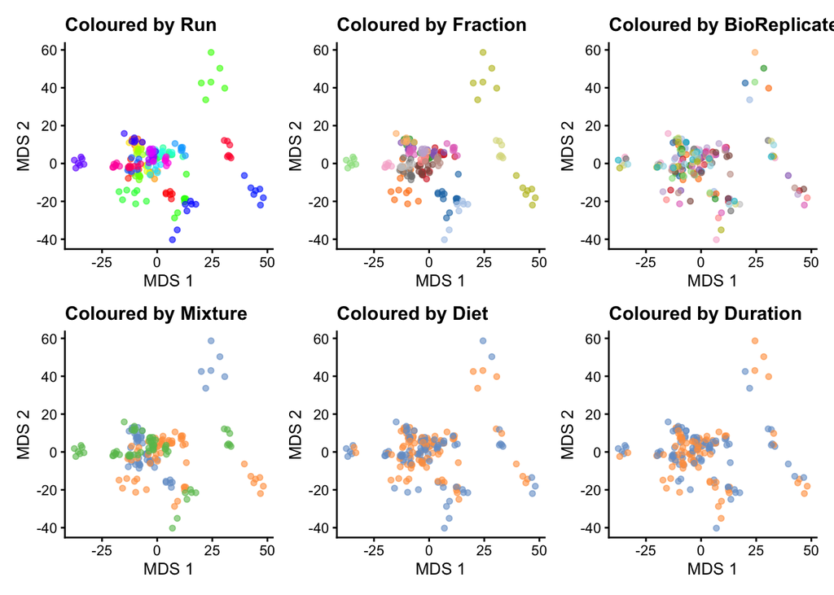

```r
plotMDS(se, colour_by = "Run") + ggtitle("Coloured by Run") +
  scale_colour_manual(values = rainbow(27)) +
  plotMDS(se, colour_by = "Fraction") + ggtitle("Coloured by Fraction") +
  plotMDS(se, colour_by = "BioReplicate") + ggtitle("Coloured by BioReplicate") +
  plotMDS(se, colour_by = "Mixture") + ggtitle("Coloured by Mixture") +
  plotMDS(se, colour_by = "Diet") + ggtitle("Coloured by Diet") +
  plotMDS(se, colour_by = "Duration") + ggtitle("Coloured by Duration") &
  theme(legend.position = "none")
```

The data exploration leads to several observations:

- The strongest source of variation is associated with the MS acquisition run.
- Part of this run effect is influenced by which fraction it contains since samples from the same fraction tend to be closer than samples from different fractions.
- It is difficult to identify an effect of mouse (biological replicate) because every run contains distinct mice. However, this does not exclude an effect of mice which has been identified as a potential source of variation and hence should still be modelled.
- There is potentially also an effect of TMT mixture since samples from the same mixtures tend to cluster together (in the center of the plot). However, this effect are more subtle to detect and difficult to disentangle from the run and fraction effects.
- Although again very subtle, we can see within each run that samples from the mice with the same diet tends to group together. However, these effects are overwhelmed by the run effects. An effect of duration is to subtle to pinpoint from the current data exploration.

Data modelling disentangles the different sources of variation, given they are properly defined in the model.

Proteomics data contain several sources of variation that need to be accounted for by the model:

1. **Treatment of interest**: we model the source of variation induced by the experimental treatment of interest as a **fixed effect**. Fixed effects are effect that are considered non-random, i.e. the treatment effect is assumed to be the same and reproducible across repeated experiments, but it is unknown and has to be estimated. We will include `Diet` as a fixed effect that models the fact that a change in diet type can induce changes in protein abundance. Similarly, we also include `Duration` as a fixed effect to model the change in protein abundance induces by the diet duration. Finally, we will also include an interaction between the two variables allowing that the changes in protein abundance induced by diet type can be different whether the mice were fed for a short or long duration.
2. **Biological replicate effect**: the experiment involves biological replication as the adipose tissue extracts were sampled from 20 mice (5 mice per Diet x Duration combination). Replicate-specific effects occurs due to uncontrollable factors, such as social behavior, feeding behavior, physical activity, occasional injury,… Two mice will never provide exactly the same sample material, even were they genetically identical and manipulated identically. These effects are typically modelled as random effects which are considered as a random sample from the population of all possible mice and are assumed to be i.i.d normally distributed with mean 0 and constant variance, $b_\text{mouse} \sim N(0,\sigma^2_\text{mouse})$. The use of random effects thus models the correlation in the data, explicitly. We expect that intensities from the same mouse are more alike than intensities between mice. Note that every mouse corresponds to one sample, i.e. one label in one mixture, that has been measured in 9 runs (one for each fraction). The mouse effect thus plays the same role as the sample effect `(1 | Mixture:Label)` in the spike-in study: without it, the 9 runs of a mouse would be treated as independent samples.

```r
length(unique(mouse$BioReplicate))
```

```
[1] 20
```

```r
length(unique(mouse$Label))
```

```
[1] 10
```

4. **Mixture effects**: the 20 mouse samples were assigned to one out of 3 mixtures. Again, we expect protein intensities from the same mixture will be more alike than those of different mixtures. Hence, we will add a random effect for mixture.

```r
table(mouse$Mixture)
```

```
 PAMI-176_Mouse_A-J  PAMI-176_Mouse_K-T PAMI-194_Mouse_U-Dd
                 54                  63                  63
```

5. **Run effects**: protein intensities that are measured within the same run will be more similar than protein intensities between runs. We will use a random effect for run to explicitly model this correlation in the data. Note that each sample has been acquired in 9 fractions, each fraction being measured in a separate run. Accounting for the effects of run will also absorb the effects of fraction.

```r
length(unique(mouse$Run))
```

```
[1] 27
```

We will model the main effects for `Diet` and `Duration`, and a `Diet:Duration` interaction, to account for proteins for which the `Diet` effect changes according to `Duration`, and vice versa, which can be written as `Diet + Duration + Diet:Duration`, shortened into `Diet * Duration` (recall the heart example in a previous course). Adding the technical sources of variation, the model becomes.

```r
model <- ~ Diet * Duration + ## (1) fixed effect for Diet and Duration with interaction
  (1 | BioReplicate) +  ## (2) random effect for biological replicate (mouse)
  (1 | Label) + ## (3) random effect for label
  (1 | Mixture) + ## (4) random effect for mixture
  (1 | Run) ## (5) random effect for MS run
```

We estimate the model with `msqrob()`.

```r
mouse <- msqrob(mouse, i = "proteins", formula = model)
```

**Difference between low fat and high fat diet after short duration**

We need to convert this question in a combination of the model parameters. We guide the contrast definition using the `ExploreModelMatrix` package. Since we are not interested in technical effects, we will only focus on the variables of interest, here `Diet * Duration`.

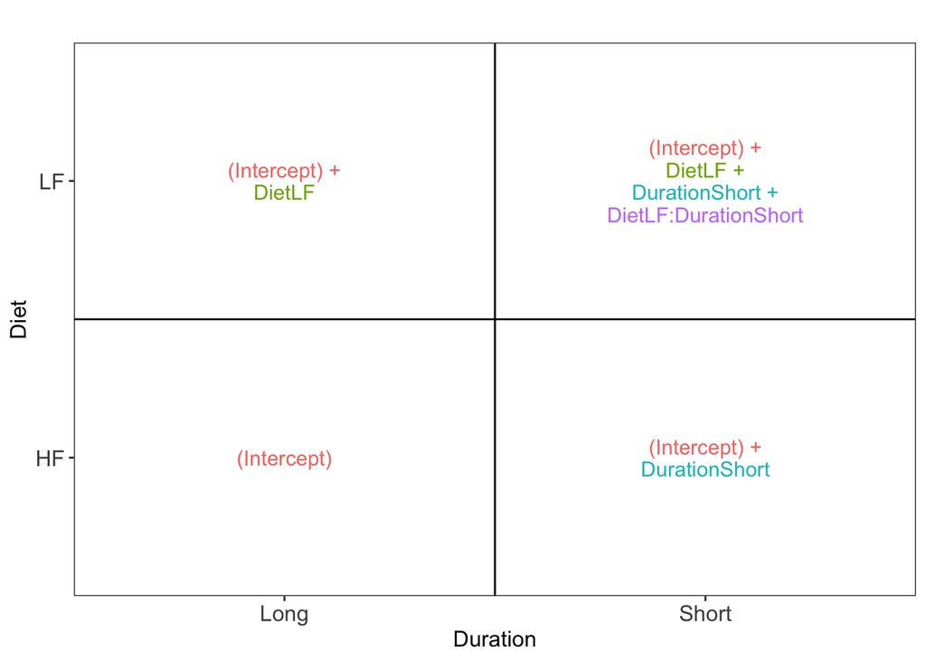

```r
library("ExploreModelMatrix")
vd <- VisualizeDesign(
    sampleData =  colData(mouse),
    designFormula = ~ Diet * Duration,
    textSizeFitted = 4
)
vd$plotlist[[1]]
```

Assessing the difference between low-fat and high-fat diets for short duration boils down to assessing the difference between the `Short_LF` and `Short_HF`. The mean for the short low-fat diet group is defined by `(Intercept) + DietLF + DurationShort + DietLF:DurationShort`. The mean for the short high-fat diet group is defined by `(Intercept) + DurationShort`. The difference between the two results in the contrast below:

```r
(L <- makeContrast(
    "DietLF + DietLF:DurationShort = 0",
    parameterNames = c("DietLF", "DietLF:DurationShort")
))
```

```
                     DietLF + DietLF:DurationShort
DietLF                                           1
DietLF:DurationShort                             1
```

```r
mouse <- hypothesisTest(mouse, i = "proteins", L)
```

Let us retrieve the result table from the `rowData`. Note that the model column is named after the column names of the contrast matrix `L`.

```r
inference <- rowData(mouse[["proteins"]])[[colnames(L)]]
head(inference)
```

```
             logFC        se        df          t        pval    adjPval
P02468 -0.03195188 0.1497508 127.77518 -0.2133670 0.831380793 0.92045731
Q61598 -0.35037677 0.1465970 127.47139 -2.3900677 0.018309085 0.11074764
P08003  0.18638918 0.4689975 121.63120  0.3974204 0.691754015 0.90769839
Q03265  0.35558692 0.1977116 125.12751  1.7985129 0.074506510 0.28427099
Q62000  0.72872636 0.2395232  89.11931  3.0424042 0.003083212 0.03475621
P17182  0.03465565 0.1434052 130.10451  0.2416625 0.809422168 0.91794950
```

The table contains the hypothesis testing results for every protein. We report the differentially abundant proteins at the 5% FDR level in a table, sorted by their p-value. We define a small helper function so that we can reuse it for the other research questions.

```r
sigTable <- function(inference, alpha = 0.05) {
  inference |>
    as.data.frame() |>
    tibble::rownames_to_column("protein") |>
    filter(adjPval < alpha) |>
    arrange(pval) |>
    knitr::kable(digits = 4)
}
sigTable(inference)
```

| protein | logFC | se | df | t | pval | adjPval |
| --- | --- | --- | --- | --- | --- | --- |
| O08528 | 0.9638 | 0.1774 | 89.6527 | 5.4341 | 0.0000 | 0.0001 |
| P47738 | 0.9784 | 0.1933 | 108.5100 | 5.0610 | 0.0000 | 0.0002 |
| Q5SWU9 | 1.6007 | 0.3234 | 124.9618 | 4.9489 | 0.0000 | 0.0002 |
| Q61233 | -0.6675 | 0.1526 | 120.7108 | -4.3750 | 0.0000 | 0.0016 |
| O54931 | -0.8373 | 0.1968 | 108.3551 | -4.2557 | 0.0000 | 0.0022 |
| Q9Z1T1 | -0.7779 | 0.1878 | 35.8608 | -4.1430 | 0.0002 | 0.0078 |
| P10126 | -0.5171 | 0.1393 | 116.2325 | -3.7115 | 0.0003 | 0.0078 |
| Q3TWL2 | -0.8688 | 0.2067 | 23.4635 | -4.2037 | 0.0003 | 0.0078 |
| Q3TIV5 | -0.6077 | 0.1599 | 61.0581 | -3.8007 | 0.0003 | 0.0078 |
| Q8K2B3 | 0.5509 | 0.1479 | 92.5480 | 3.7247 | 0.0003 | 0.0078 |
| Q6P9Q4 | -1.0187 | 0.2488 | 26.8479 | -4.0941 | 0.0003 | 0.0078 |
| Q9CR00 | -0.4705 | 0.1301 | 76.7912 | -3.6172 | 0.0005 | 0.0110 |
| Q9WVA4 | -0.4802 | 0.1378 | 97.0439 | -3.4836 | 0.0007 | 0.0142 |
| Q8R164 | 0.3893 | 0.1118 | 67.5952 | 3.4829 | 0.0009 | 0.0155 |
| Q9D1M0 | -0.5631 | 0.1699 | 79.2198 | -3.3142 | 0.0014 | 0.0229 |
| O89079 | -0.5373 | 0.1637 | 64.1541 | -3.2819 | 0.0017 | 0.0244 |
| Q99K85 | -0.6007 | 0.1842 | 70.0912 | -3.2611 | 0.0017 | 0.0244 |
| Q9D832 | -0.5262 | 0.1570 | 36.9266 | -3.3514 | 0.0019 | 0.0244 |
| O88456 | -0.7443 | 0.2170 | 28.4068 | -3.4299 | 0.0019 | 0.0244 |
| P28271 | 0.3728 | 0.1202 | 119.6760 | 3.1007 | 0.0024 | 0.0299 |
| Q61792 | -0.7830 | 0.2568 | 103.1546 | -3.0488 | 0.0029 | 0.0345 |
| Q62000 | 0.7287 | 0.2395 | 89.1193 | 3.0424 | 0.0031 | 0.0348 |
| Q60739 | 0.5299 | 0.1727 | 46.4263 | 3.0679 | 0.0036 | 0.0387 |
| O08586 | 0.5985 | 0.1804 | 17.5730 | 3.3169 | 0.0039 | 0.0407 |
| Q8C1B7 | -0.5833 | 0.1991 | 63.5916 | -2.9305 | 0.0047 | 0.0466 |
| Q8BUR4 | -0.7277 | 0.2327 | 21.4505 | -3.1266 | 0.0050 | 0.0478 |
| P63001 | -0.6380 | 0.2126 | 31.4756 | -3.0015 | 0.0052 | 0.0480 |

We can use the table above directly to build a volcano plot using `ggplot2` functionality.

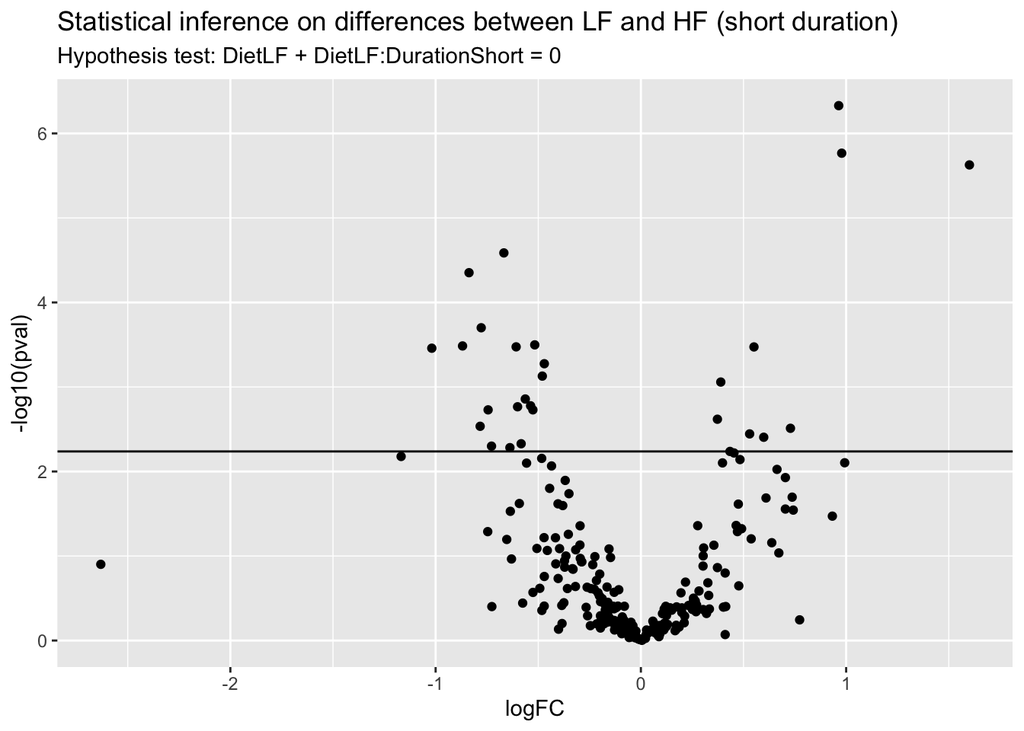

```r
ggplot(inference) +
    aes(x = logFC, y = -log10(pval)) +
    geom_hline(yintercept = -log10(inference$pval[which.min(abs(inference$adjPval - 0.05))] )) +
    geom_point() +
    ggtitle("Statistical inference on differences between LF and HF (short duration)",
            paste("Hypothesis test:", colnames(L), "= 0"))
```

In this example (remember this is a subset of the complete data set), only a few proteins pass the significance threshold of 5% FDR.

**Difference between low fat and high fat diet after long duration**

Following the same approach as above, the hypothesis test becomes:

```r
L <- makeContrast("DietLF = 0", parameterNames = "DietLF")
mouse <- hypothesisTest(mouse, i = "proteins", L)
inference <- rowData(mouse[["proteins"]])[[colnames(L)]]
sigTable(inference)
```

| protein | logFC | se | df | t | pval | adjPval |
| --- | --- | --- | --- | --- | --- | --- |
| P61924 | -1.1192 | 0.1720 | 63.5456 | -6.5063 | 0.0000 | 0.0000 |
| Q924P3 | -6.5712 | 0.6115 | 14.2327 | -10.7455 | 0.0000 | 0.0000 |
| Q8R164 | 0.6107 | 0.1157 | 67.5952 | 5.2767 | 0.0000 | 0.0001 |
| O89079 | -0.8472 | 0.1878 | 64.1541 | -4.5113 | 0.0000 | 0.0017 |
| Q920E5 | -0.7868 | 0.1792 | 45.9298 | -4.3901 | 0.0001 | 0.0027 |
| Q76MZ3 | -0.4623 | 0.1096 | 70.5912 | -4.2169 | 0.0001 | 0.0027 |
| Q8CJ12 | -4.4895 | 0.8944 | 19.0222 | -5.0193 | 0.0001 | 0.0027 |
| Q9WUA2 | -0.4263 | 0.1014 | 58.4971 | -4.2041 | 0.0001 | 0.0028 |
| P32261 | 0.6978 | 0.2090 | 113.1754 | 3.3393 | 0.0011 | 0.0308 |
| Q8K1Z0 | 0.6733 | 0.1914 | 34.4777 | 3.5176 | 0.0012 | 0.0308 |
| O35598 | -1.1563 | 0.3276 | 19.6868 | -3.5298 | 0.0021 | 0.0484 |

And we plot the results.

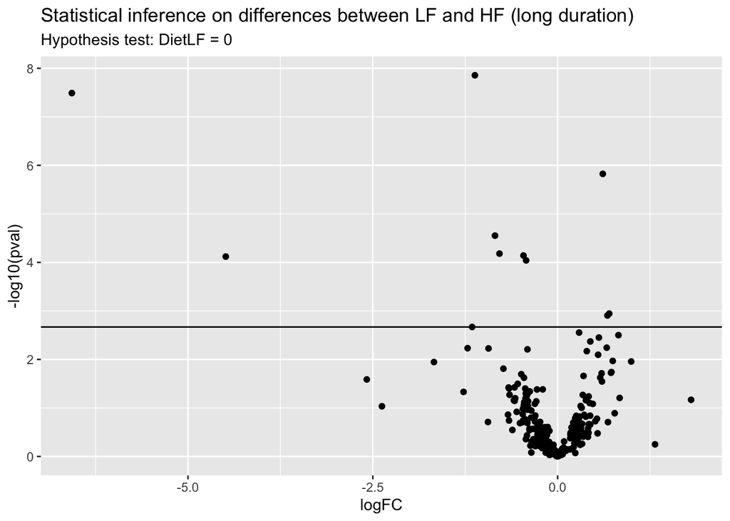

```r
ggplot(inference) +
    aes(x = logFC, y = -log10(pval)) +
    geom_hline(yintercept = -log10(inference$pval[which.min(abs(inference$adjPval - 0.05))] )) +
    geom_point() +
    ggtitle("Statistical inference on differences between LF and HF (long duration)",
            paste("Hypothesis test:", colnames(L), "= 0"))
```

Again, only a few proteins come out differentially abundant between the two diets, but after a long diet duration.

**Average difference between low fat and high fat diet**

One may want to identify the set of proteins that are systematically differentially abundant between diets, irrespective of the duration. To answer this question, we want to infer on the average difference between group `LF` and group `HF`. The average low-fat diet is defined by `((Intercept) + DietLF + DurationShort + DietLF:DurationShort + (Intercept) + DietLF)/2`. The average high-fat diet group is defined by `((Intercept) + DurationShort + (Intercept))/2`. The difference between the two results in the hypothesis test below:

```r
L <- makeContrast(
    "DietLF + (DietLF:DurationShort)/2 = 0",
    parameterNames = c("DietLF", "DietLF:DurationShort")
)
mouse <- hypothesisTest(mouse, i = "proteins", L)
inference <- rowData(mouse[["proteins"]])[[colnames(L)]]
sigTable(inference)
```

| protein | logFC | se | df | t | pval | adjPval |
| --- | --- | --- | --- | --- | --- | --- |
| Q8R164 | 0.5000 | 0.0807 | 67.5952 | 6.1929 | 0.0000 | 0.0000 |
| Q924P3 | -3.6008 | 0.3436 | 14.2327 | -10.4803 | 0.0000 | 0.0000 |
| P61924 | -0.6421 | 0.1100 | 63.5456 | -5.8349 | 0.0000 | 0.0000 |
| O89079 | -0.6923 | 0.1252 | 64.1541 | -5.5306 | 0.0000 | 0.0000 |
| P47738 | 0.6988 | 0.1460 | 108.5100 | 4.7874 | 0.0000 | 0.0003 |
| Q61233 | -0.5614 | 0.1214 | 120.7108 | -4.6230 | 0.0000 | 0.0004 |
| Q62000 | 0.7755 | 0.1808 | 89.1193 | 4.2884 | 0.0000 | 0.0015 |
| Q76MZ3 | -0.3050 | 0.0703 | 70.5912 | -4.3361 | 0.0000 | 0.0015 |
| O54931 | -0.6192 | 0.1501 | 108.3551 | -4.1246 | 0.0001 | 0.0019 |
| Q8K1Z0 | 0.5355 | 0.1195 | 34.4777 | 4.4822 | 0.0001 | 0.0019 |
| P07759 | 0.5058 | 0.1237 | 101.8980 | 4.0880 | 0.0001 | 0.0020 |
| Q5SWU9 | 0.9791 | 0.2439 | 124.9618 | 4.0139 | 0.0001 | 0.0021 |
| Q3TWL2 | -0.6537 | 0.1448 | 23.4635 | -4.5150 | 0.0001 | 0.0029 |
| Q99K85 | -0.5464 | 0.1385 | 70.0912 | -3.9439 | 0.0002 | 0.0033 |
| P10126 | -0.4029 | 0.1060 | 116.2325 | -3.8000 | 0.0002 | 0.0038 |
| Q3TIV5 | -0.5151 | 0.1357 | 61.0581 | -3.7951 | 0.0003 | 0.0053 |
| Q9D1M0 | -0.4760 | 0.1281 | 79.2198 | -3.7162 | 0.0004 | 0.0055 |
| Q8BH35 | 0.5693 | 0.1564 | 89.5586 | 3.6394 | 0.0005 | 0.0063 |
| Q8BUR4 | -0.8314 | 0.2030 | 21.4505 | -4.0947 | 0.0005 | 0.0065 |
| Q9R069 | 0.3593 | 0.1006 | 88.8423 | 3.5718 | 0.0006 | 0.0071 |
| Q8CJ12 | -2.2423 | 0.5692 | 19.0222 | -3.9391 | 0.0009 | 0.0104 |
| Q9WUA2 | -0.2325 | 0.0684 | 58.4971 | -3.3991 | 0.0012 | 0.0138 |
| O54774 | -0.4957 | 0.1542 | 76.5716 | -3.2139 | 0.0019 | 0.0207 |
| Q8CI59 | 0.3728 | 0.1173 | 39.6654 | 3.1794 | 0.0029 | 0.0296 |
| O08586 | 0.5370 | 0.1573 | 17.5730 | 3.4143 | 0.0032 | 0.0315 |
| Q99J45 | -1.0898 | 0.3314 | 20.4802 | -3.2882 | 0.0036 | 0.0342 |
| Q920E5 | -0.3638 | 0.1193 | 45.9298 | -3.0492 | 0.0038 | 0.0349 |
| Q61792 | -0.5583 | 0.1941 | 103.1546 | -2.8760 | 0.0049 | 0.0433 |
| Q9Z1T1 | -0.4103 | 0.1382 | 35.8608 | -2.9683 | 0.0053 | 0.0449 |
| Q9Z1X4 | 0.5426 | 0.1836 | 36.7539 | 2.9547 | 0.0054 | 0.0449 |

And we plot the results.

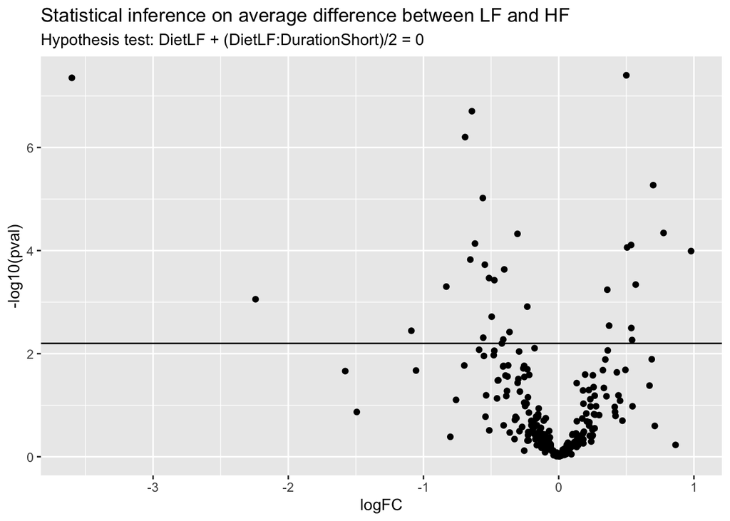

```r
ggplot(inference) +
    aes(x = logFC, y = -log10(pval)) +
    geom_hline(yintercept = -log10(inference$pval[which.min(abs(inference$adjPval - 0.05))] )) +
    geom_point() +
    ggtitle("Statistical inference on average difference between LF and HF",
            paste("Hypothesis test:", colnames(L), "= 0"))
```

**Interaction: does the diet effect change according to duration?**

We will now explore whether the effect of diet on protein abundance may be affected by duration, i.e. we want to infer on the difference of differences. The difference between hypothesis 1 and 2 is `(DietLF + DietLF:DurationShort) - (DietLF)` and results in the hypothesis below:

We can proceed with the same statistical pipeline.

```r
L <- makeContrast(
    "DietLF:DurationShort = 0",
    parameterNames = "DietLF:DurationShort"
)
mouse <- hypothesisTest(mouse, i = "proteins", L)
inference <- rowData(mouse[["proteins"]])[[colnames(L)]]
sigTable(inference)
```

| protein | logFC | se | df | t | pval | adjPval |
| --- | --- | --- | --- | --- | --- | --- |
| Q924P3 | 5.9407 | 0.7394 | 14.2327 | 8.0348 | 0e+00 | 0.0003 |
| O08528 | 1.2022 | 0.2696 | 89.6527 | 4.4589 | 0e+00 | 0.0029 |
| P61924 | 0.9543 | 0.2197 | 63.5456 | 4.3444 | 1e-04 | 0.0042 |
| P32261 | -0.9876 | 0.2780 | 113.1754 | -3.5528 | 6e-04 | 0.0345 |
| Q8CJ12 | 4.4944 | 1.1361 | 19.0222 | 3.9561 | 8e-04 | 0.0419 |

And we plot the results.

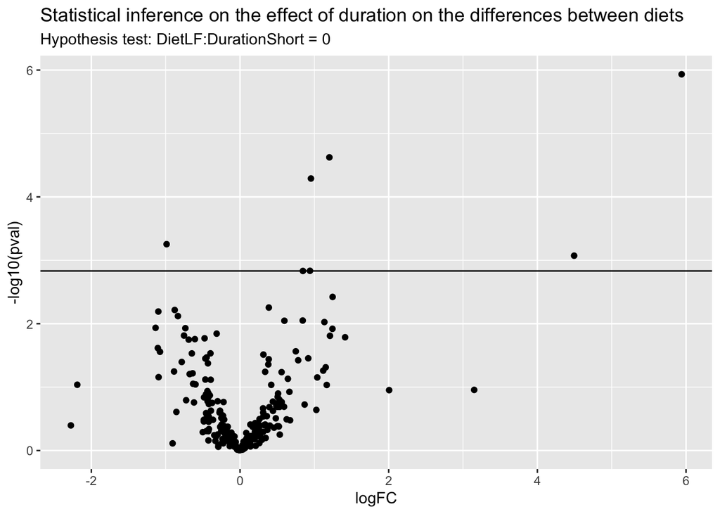

```r
ggplot(inference) +
    aes(x = logFC, y = -log10(pval)) +
    geom_hline(yintercept = -log10(inference$pval[which.min(abs(inference$adjPval - 0.05))] )) +
    geom_point() +
    ggtitle("Statistical inference on the effect of duration on the differences between diets",
            paste("Hypothesis test:", colnames(L), "= 0"))
```

## 7 References

Huang, Ting, Meena Choi, Manuel Tzouros, et al. 2020. “MSstatsTMT: Statistical Detection of Differentially Abundant Proteins in Experiments with Isobaric Labeling and Multiple Mixtures.” *Mol. Cell. Proteomics* 19 (10): 1706–23.

Plubell, Deanna L, Phillip A Wilmarth, Yuqi Zhao, et al. 2017. “Extended Multiplexing of Tandem Mass Tags (TMT) Labeling Reveals Age and High Fat Diet Specific Proteome Changes in Mouse Epididymal Adipose Tissue.” *Mol. Cell. Proteomics* 16 (5): 873–90.